# Introduction to TwoStepSDFM

# Overview

The `TwoStepSDFM` package provides a fast and memory-efficient implementation of the cross-validation, prediction[^1], and two-step estimation procedure for mixed-frequency *sparse dynamic factor models* (SDFM) outlined in Franjic and Schweikert (2024). The routines in this package also directly handle heterogeneous publication lags of the data, which can lead to missing observations at the end of the observation period (so-called *ragged edges*).

We estimate the sparse loading matrix via *sparse principal components analysis* (SPCA) (Zou, Hastie, and Tibshirani 2006). The latent states are then filtered via a univariate representation of the *Kalman Filter and Smoother* (KFS) as described in Koopman and Durbin (2000).

Our approach is a direct generalisation of the classical two-step estimator for dense DFMs described in Giannone, Reichlin, and Small (2008) and Doz, Giannone, and Reichlin (2011). Differing from the classical model, however, we allow regularisation to shrink some of the factor loadings towards or directly to zero. This is achieved by elastic-net type size constraints introduced to the PCA’s least squares problem according to Zou, Hastie, and Tibshirani (2006). We also explicitly account for cross-sectional correlation in the measurement error. For more details see Franjic and Schweikert (2024).

# Main Features

- **Fast Model Simulation**: The `simFM()` function provides a flexible framework to simulate mixed-frequency data with ragged edges from an approximate DFM.
- **Estimation of the Number of Factors**: The `noOfFactors()` function uses the Onatski (2009) procedure to estimate the number of factors efficiently while providing good finite sample performance.
- **Fast Model Estimation**: The `twoStepSDFM()` function provides a fast, memory-efficient, and convenient implementation of the two-step estimator outlined in Franjic and Schweikert (2024).
- **Fast Hyper-Parameter Cross-Validation**: The `crossVal()` function provides a fast and parallel cross-validation wrapper to retrieve the optimal hyper-parameters using time-series cross-validation (Hyndman and Athanasopoulos 2018) with random hyper-parameter search (Bergstra and Bengio 2012).
- **Fast Model Prediction**: The `nowcast()` function is a highly convenient prediction function for backcasts, nowcasts, and forecasts of multiple targets. It automatically takes care of all issues arising with mixed-frequency data and ragged edges.
- **Compatibility**: All functions take advantage of `C++` for enhanced speed and memory-efficiency.

# Side Features

- **Fast dense DFM estimation and prediction**: The `nowcast()` function is also able to produce predictions of a dense DFM according to Giannone, Reichlin, and Small (2008). The function `twoStepDenseDFM()` additionally exposes an estimation procedure for the dense two-step estimator.
- **Fast SPCA**: `sparsePCA()` exposes the internal `C++`-backed SPCA routine in `R`. This provides access to a fast and memory-efficient SPCA estimation routine as implemented by Zou and Hastie (2020) in pure `R`.
- **Fast Kalman Filter and Smoother**: The `kalmanFilterSmoother()` function exposes the internal `C++`-backed KFS routine.

# Example Usage

Below, we will outline the usage of the main features of this package. To this end, we start by simulating what we refer to as a *pseudo mixed-frequency data vintage*.[^2] This vintage includes a set of stationary mixed-frequency variables, a vector indicating the variables’ frequencies, and a vector indicating the variables’ delays. Afterwards, we go over a step-by-step example on how to validate the hyper-parameters, estimate the model parameters, and predict using the data vintage.

## Simulate Data

We start our exposé by simulating data from an approximate DFM with measurement equation
$$\boldsymbol{x}_t = \boldsymbol{\Lambda} \boldsymbol{f}_{t} +
\boldsymbol{\xi}_t,\quad \boldsymbol{\xi}_t \sim
\mathcal{N}(\boldsymbol{\mu}, \boldsymbol{\Sigma}_{\xi}),$$
and transition equation
$$\boldsymbol{f}_t = \sum_{p=1}^P\boldsymbol{\Phi}_p \boldsymbol{f}_{t-p}
+ \boldsymbol{\epsilon}_t,\quad \boldsymbol{\epsilon}_t \sim
\mathcal{N}(\boldsymbol{0}, \boldsymbol{\Sigma}_{f}),$$
for $t = 1, \dots,T$. The vector $\boldsymbol{x}_t := (x_{n,t})_{n=1}^{N}$ represents the vector of all *monthly* variables, including those which will be *aggregated into a quarterly representation* (quarterfied) later. $\boldsymbol{\Lambda} := (\lambda_{n,r})_{n,r=1}^{N,R}$ is the factor loading matrix that distributes the dynamics of the $R$ factors, represented by $\boldsymbol{f}_t := (f_{r,t})_{r=1}^R$, onto the data. $\boldsymbol{\Phi}_p:=(\phi_{r,s,p})_{r,s=1}^{R,R}$ is the $p$th transition VAR coefficient matrix. The vectors $\boldsymbol{\xi}_t := (\xi_{n,t})_{n=1}^N$ and $\boldsymbol{\epsilon}_t := (\epsilon_{r,t})_{r=1}^R$ represent the measurement and transition error, respectively. $\boldsymbol{\mu} := (\mu_{n})_{n=1}^N$ and $\boldsymbol{\Sigma}_{\xi}:=(\sigma_{\xi;n,m})_{n,m=1}^{N,N}$ represent the measurement error mean and measurement error variance-covariance matrix, respectively, and $\boldsymbol{\Sigma}_{f}:=(\sigma_{f;r,s})_{r,s=1}^{R,R}$ represents the transition error variance-covariance matrix.[^3]

As our goal is to simulate mixed-frequency data, we will quarterfy five variables, i.e. 10% of all variables simulated below. We do so by using the geometric mean as described in Mariano and Murasawa (2003):
$$\boldsymbol{x}^*_{t}:= \frac{1}{3}\left(\boldsymbol{x}_{t} +
2\boldsymbol{x}_{t-1} + 3\boldsymbol{x}_{t-2} + 2\boldsymbol{x}_{t-3} +
\boldsymbol{x}_{t-4}\right)$$
for $t=3, 6, \dots,T - \mathrm{mod}(T,3)$. Note that this implies that the simulated data will always start in the first month of the corresponding quarter. The `simFM()` function will therefore check the `starting_date` when data gets quarterfied and turned into a `zoo` object.

Lastly, we also want to impose a ragged edge structure onto the data. The ragged edges are set via the `delay` parameter. Note that the `delay` parameter differs from the `delay` parameter of the other estimation functions below. In the case of `simFM()`, `delay` refers to the number of months for monthly data and the number of quarters for quarterly data that will be missing. For example, consider `delay <- c(1, 1)` and assume the variable with index `1` will be quarterfied. In that case, the variable with index `1` will be delayed by 1 quarter, i.e., it will be missing 3 observations at the end of the panel. The variable with index `2` will be delayed by 1 month, i.e., it will be missing 1 observation at the end of the panel. In all other instances, including the `delay` object returned by `simFM()`, `delay` represents the number of months since the most recent publication.

As a final remark, note that all RNG calls happen inside `C++`. Therefore, `set.seed()` will not affect the results of `simFM()`. Rather all random processes are governed by the `seed` argument provided to the function. The `set.seed()` call in the chunk below is only used for the reproducibility of the generation of the DFM parameters.

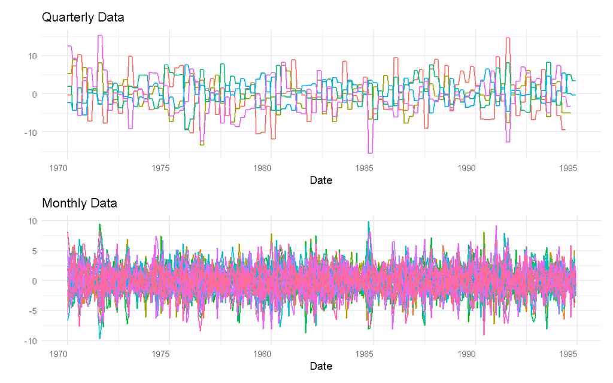

```r
seed <- 02102025
set.seed(seed)
no_of_obs <- 300
no_of_vars <- 50
no_of_factors <- 3
trans_error_var_cov <- diag(1, no_of_factors)
loading_matrix <- matrix(rnorm(no_of_vars * no_of_factors), no_of_vars, no_of_factors)
meas_error_mean <- rep(0, no_of_vars)
meas_error_var_cov <- diag(1, no_of_vars)
trans_var_coeff <- cbind(diag(0.5, no_of_factors), -diag(0.25, no_of_factors))
factor_lag_order <- 2
delay <- c(2, 1, floor(rexp(no_of_vars - 2, 1)))
quarterfy <- TRUE
quarterly_variable_ratio <- 0.1
corr <- TRUE
beta_param <- 2
burn_in <- 999
starting_date <- "1970-01-01"
rescale <- FALSE
check_stationarity <- TRUE
stationarity_check_threshold <- 1e-10
factor_model <- simFM(no_of_obs = no_of_obs, no_of_vars = no_of_vars,
                      no_of_factors = no_of_factors, loading_matrix = loading_matrix,
                      meas_error_mean = meas_error_mean, meas_error_var_cov = meas_error_var_cov,
                      trans_error_var_cov = trans_error_var_cov, trans_var_coeff = trans_var_coeff,
                      factor_lag_order = factor_lag_order, delay = delay, quarterfy = quarterfy,
                      quarterly_variable_ratio  = quarterly_variable_ratio, corr = corr,
                      beta_param = beta_param, seed = seed, burn_in = burn_in,
                      starting_date = starting_date, rescale = rescale,
                      check_stationarity = check_stationarity,
                      stationarity_check_threshold = stationarity_check_threshold)
spca_plots <- plot(factor_model, axis_text_size = 10, legend_title_text_size = 5)
spca_plots$`Data Plots`
```

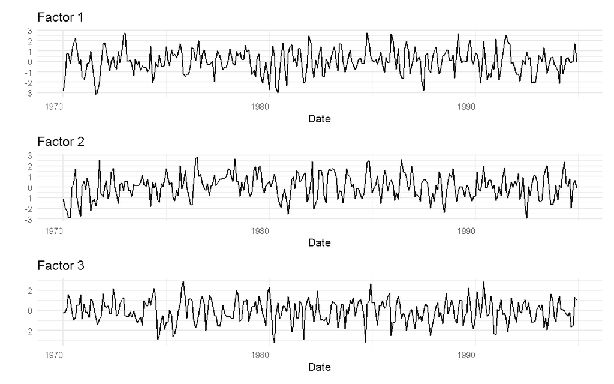

```r
spca_plots$`Factor Time Series Plots`
```

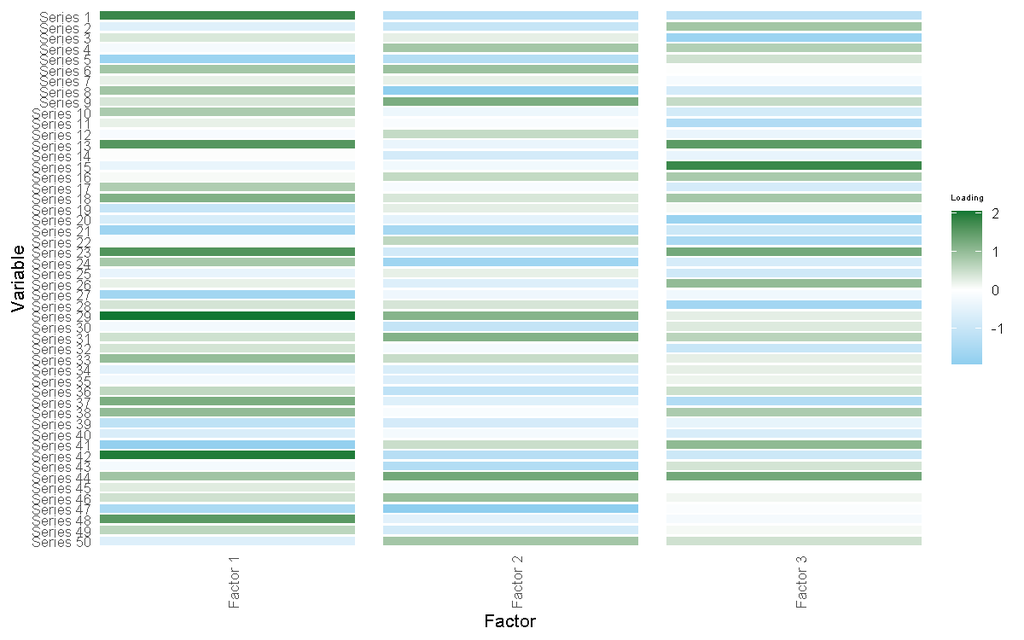

```r
spca_plots$`Loading Matrix Heatmap`
```

## Estimate the Number of Factors

We also need to set a confidence threshold as a stopping rule of the testing procedure. In general, for finite samples, the Onatski (2009) procedure works quite well and in our experience better than information-based criteria, especially when working with data simulated from an SDFM with a high degree of sparsity. However, we also found that in some cases, the testing procedure seems to underestimate the number of factors if the threshold is set too strictly. Users should therefore set `confidence_threshold` comparatively large if the cost of underestimating the number of factors, i.e., including too few factors, is large.

```r
mtly_data <- scale(factor_model$data[, which(factor_model$frequency == 12)])
no_of_fact_test <- noOfFactors(mtly_data, min_no_factors = 1, max_no_factors = 7,
                                  confidence_threshold = 0.2)
print(no_of_fact_test)
```

```
#> Results of the Onatsky testing procedure:
#> The estimated no. of factors is 3 with a p-value of 0.375 and a critical value of alpha = 0.2
#>
#> Results of the Bai and Ng information criteria:
#> No. of factors according to IC1: 7
#> No. of factors according to IC2: 7
#> No. of factors according to IC3: 7
```

## Cross-Validate the Hyper-Parameters

With an estimate of the number of factors at hand, we proceed to infer the hyper-parameters. Just as above, we standardise the data prior to the analysis. Here, however, we provide the full mixed-frequency data set, as the function handles the issues of the mixed-frequency structure internally.

```r
no_of_mtly_vars <- sum(factor_model$frequency == 12)
all_data <- scale(factor_model$data)
cross_val_res <- crossVal(data = all_data, variable_of_interest = 1, fcast_horizon = 0,
                                 delay = factor_model$delay, frequency = factor_model$frequency,
                                 no_of_factors = no_of_fact_test$test$no_of_factors, seed = seed,
                                 min_ridge_penalty = 1e-6, max_ridge_penalty = 1e+5, cv_repetitions = 5,
                                 cv_size = 100, lasso_penalty_type = "selected", min_max_penalty = c(5, no_of_mtly_vars),
                                 verbose = FALSE)
print(cross_val_res)
```

```
#> Cross-Validation Results
#> =========================================================================
#> Cross-Validation Error:  0.472523
#> Optimum Ridge Penalty :  1547.582
#>
#> # of non-zero Loadings per Factor
#> Factor  1             : 40
#> Factor  2             : 16
#> Factor  3             : 19
#> =========================================================================
#>
#> BIC Results
#> =========================================================================
#> BIC                   :  0.3747073
#> Optimum Ridge Penalty :  0
#>
#> # of non-zero Loadings per Factor
#> Factor  1             : 45
#> Factor  2             : 45
#> Factor  3             : 45
#> =========================================================================
```

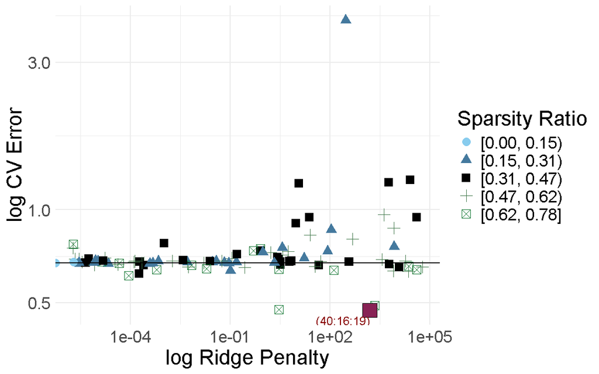

```r
cross_val_plot <- plot(cross_val_res)
cross_val_plot$`CV Results`
```

## Estimate the Parameters of the SDFM

Before turning to the main prediction routine, we want to focus on the estimation of the model parameters first. While written with prediction as main focus, our package also provides the means to estimate the model parameters. For an SDFM, this is handled by the `twoStepSDFM()` function below. Its usage is straightforward. Note, however, that the function only accepts monthly data.

```r
mtly_data <- scale(factor_model$data[, which(factor_model$frequency == 12)])
mtly_delay <- factor_model$delay[which(factor_model$frequency == 12)]
inferred_no_of_selected <- cross_val_res$CV$`Min. CV`[3:(3 + no_of_fact_test$test$no_of_factors - 1)]
inferred_ridge_penalty <- cross_val_res$CV$`Min. CV`[1]
sdfm_fit <- twoStepSDFM(data = mtly_data, delay = mtly_delay, selected = inferred_no_of_selected,
                        no_of_fact_test$test$no_of_factors, ridge_penalty = inferred_ridge_penalty)
print(sdfm_fit)
```

```
#> Simulated Dynamic Factor Model
#> =========================================================================
#> No. of Observations                        : 300
#> No. of Variables                           : 45
#> No. of Factors                             : 3
#> Factor Lag Order                           : 2
#> No. of zero elements in the loading matrix : 60
#> =========================================================================
#> Head of the factors :
#>             Factor 1  Factor 2 Factor 3
#> Jan 1970 -10.2876529  3.302636 3.737877
#> Feb 1970  -6.5705960 -1.752246 3.513527
#> Mar 1970  -0.6138966 -6.679130 4.198856
#> Apr 1970  -1.3973223 -6.893427 8.838713
#> May 1970  -4.8644665 -5.378115 7.070411
#> Tail of the factors :
#>             Factor 1  Factor 2   Factor 3
#> Aug 1994   0.6358366  1.667165 -1.8261503
#> Sept 1994 -4.1323004 -6.608666 -1.4170338
#> Oct 1994  -0.9269175 -2.136796 -1.1725775
#> Nov 1994   6.3287872 -1.251908  0.5935398
#> Dec 1994  -1.6773825 -1.270249  1.4509413
#> Head of the loading matrix :
#>             [,1]       [,2]       [,3]
#> [1,]  0.26945380  0.0000000 -0.2652319
#> [2,]  0.11117513  0.0000000  0.0000000
#> [3,] -0.05484467 -0.9727244  0.0000000
#> [4,]  0.24172759  0.2761174  0.0000000
#> [5,]  0.00000000 -0.1632593 -0.2216994
#> Tail of the loading matrix :
#>               [,1]        [,2]      [,3]
#> [41,]  0.216726824  0.00000000 0.0000000
#> [42,] -0.297284626  0.00000000 0.2309382
#> [43,]  0.115015121 -0.62532497 0.0000000
#> [44,]  0.003274602 -0.65080152 0.3161383
#> [45,]  0.000000000  0.06522026 0.0000000
#> =========================================================================
```

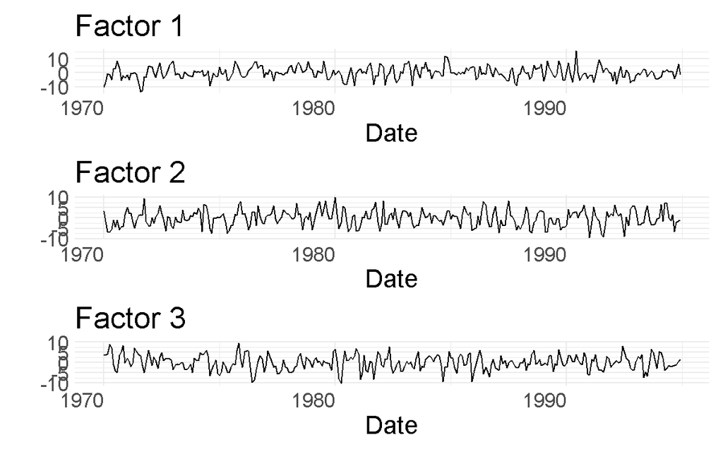

```r
sdfm_fit_plot <- plot(sdfm_fit)
sdfm_fit_plot$`Factor Time Series Plots`
```

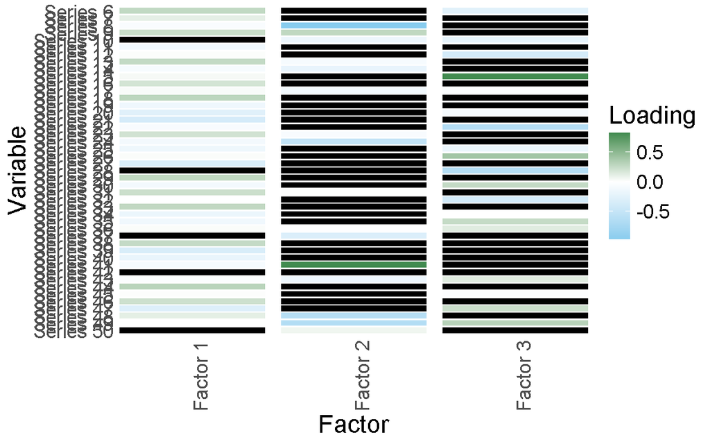

```r
sdfm_fit_plot$`Loading Matrix Heatmap`
```

## Predict Target Variables

Finally, we turn to the nowcasting routine. Fundamentally, this routine is an unrestricted factor augmented MIDAS model as described in Marcellino and Schumacher (2010). For each target, we use each other target, each additional quarterly predictor, and quarterfied factor, and predict the target via an individual (AR)DL model. The exact autoregressive and predictor lag order are inferred internally via the BIC for each equation. The final forecast is then given by the unweighted mean of all individual (AR)DL model forecasts.

After cross-validation, we are set to directly predict the target variables. Here, just as with `crossVal()`, we are also able to provide the complete mixed-frequency data set. Note that, in contrast to the cross-validation function, it is possible to predict multiple targets across multiple horizons at once. One should keep in mind, however, that the optimal hyper-parameters are retrieved for a specific target and horizon (in our case the nowcast of the first quarterly variable). Therefore, in a serious prediction exercise, one should always tune the hyper-parameters for each target and horizon specifically.[^7]

To show off the abilities of this function, however, we still predict multiple targets and horizons. The first target is lagged by two quarters, while the second is lagged by only one. The maximum forecasting horizon is set to two. This means that for both targets we will forecast two steps ahead. For target one we will additionally compute a backcast and a nowcast. For target two only a nowcast will be computed. In general, `max_fcast_horizon` governs the number of step-ahead forecasts computed. nowcasts and backcasts are automatically computed depending on the delay of the targets.

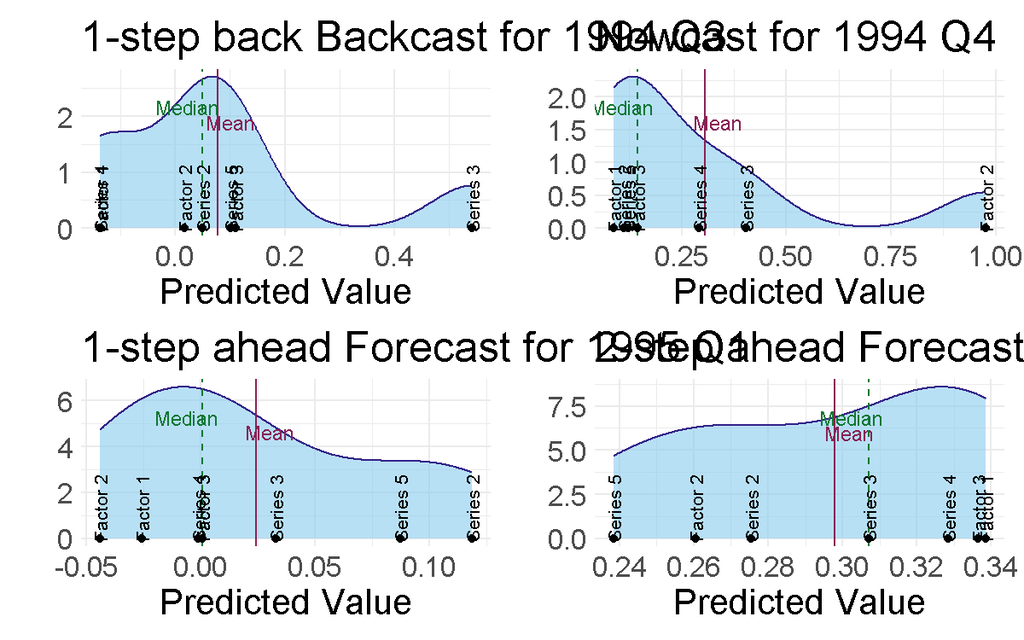

```r
all_data <- scale(factor_model$data)
inferred_no_of_selected <- cross_val_res$CV$`Min. CV`[3:(3 + no_of_fact_test$test$no_of_factors - 1)]
inferred_ridge_penalty <- cross_val_res$CV$`Min. CV`[1]
nc_results <- nowcast(data = all_data, variables_of_interest = c(1, 2), max_fcast_horizon = 2,
                      delay = factor_model$delay, ridge_penalty = inferred_ridge_penalty, selected = inferred_no_of_selected, frequency = factor_model$frequency, no_of_factors = no_of_fact_test$test$no_of_factors)
nc_plot <- plot(nc_results)
nc_plot$`Single Pred. Fcast Density Plots Series 1`
```

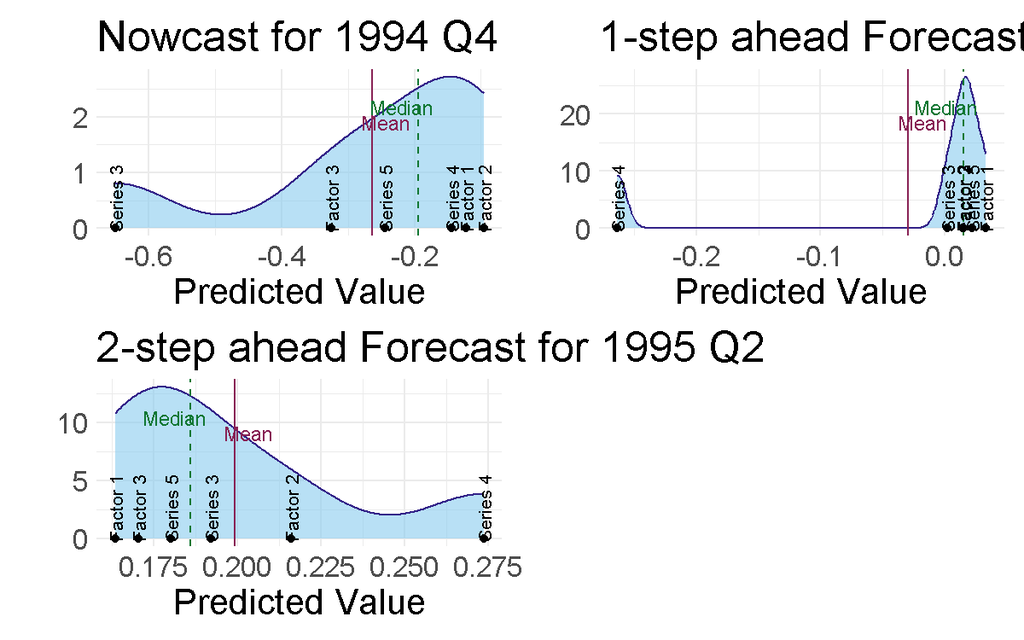

```r
nc_plot$`Single Pred. Fcast Density Plots Series 2`
```

# References

Bai, Jushan, and Serena Ng. 2002. “Determining the Number of Factors in Approximate Factor Models.” *Econometrica* 70 (1): 191–221.

Bergstra, James, and Yoshua Bengio. 2012. “Random Search for Hyper-Parameter Optimization.” *Journal of Machine Learning Research* 13 (2).

Doz, Catherine, Domenico Giannone, and Lucrezia Reichlin. 2011. “A two-step estimator for large approximate dynamic factor models based on Kalman filtering.” *Journal of Econometrics* 164 (1): 188–205. https://doi.org/10.1016/j.jeconom.2011.02.012.

Franjic, Domenic, and Karsten Schweikert. 2024. “Nowcasting Macroeconomic Variables with a Sparse Mixed Frequency Dynamic Factor Model.” *Available at SSRN 4733872*.

Giannone, Domenico, Lucrezia Reichlin, and David Small. 2008. “Nowcasting: The Real-Time Informational Content of Macroeconomic Data.” *Journal of Monetary Economics* 55 (4): 665–76. https://doi.org/10.1016/j.jmoneco.2008.05.010.

Hyndman, Rob J., and George Athanasopoulos. 2018. *Forecasting: Principles and Practice*. 3rd ed. Melbourne, Australia: OTexts Melbourne.

Koopman, Siem Jan, and James Durbin. 2000. “Fast Filtering and Smoothing for Multivariate State Space Models.” *Journal of Time Series Analysis* 21 (3): 281–96.

Marcellino, Massimiliano, and Christian Schumacher. 2010. “Factor MIDAS for nowcasting and forecasting with ragged-edge data: A model comparison for German GDP.” *Oxford Bulletin of Economics and Statistics* 72 (4): 518–50.

Mariano, Roberto S., and Yasutomo Murasawa. 2003. “A New Coincident Index of Business Cycles Based on Monthly and Quarterly Series.” *Journal of Applied Econometrics* 18 (4): 427–43. https://doi.org/10.1002/jae.695.

Onatski, Alexei. 2009. “Testing Hypotheses about the Number of Factors in Large Factor Models.” *Econometrica* 77 (5): 1447–79.

Zou, Hui, and Trevor Hastie. 2020. *Elasticnet: Elastic-Net for Sparse Estimation and Sparse PCA*. https://CRAN.R-project.org/package=elasticnet.

Zou, Hui, Trevor Hastie, and Robert Tibshirani. 2006. “Sparse Principal Component Analysis.” *Journal of Computational and Graphical Statistics* 15 (2): 265–86.

[^1]: Note that, due to the mixed-frequency structure, prediction here includes backcasts, nowcasts, and forecasts of the target variable.
[^2]: We use the term *pseudo* as real-world vintages often contain data that is not necessarily stationary. These variables often rely on an individual transformation code. As the package does not provide means of automatically rendering data stationary, we assume all the data to be stationary. Users are thus advised to transform their data separately prior to the analysis.
[^3]: Note that the choice of a zero-mean transition error is deliberate. As we work with a stationary transition equation, for every transition error mean $\boldsymbol{\nu}$ it holds that $\mathbb{E}(\boldsymbol{x}_t)=\boldsymbol{\mu} + \boldsymbol{\Lambda}\left(\boldsymbol{I} - \sum_{p=1}^P\boldsymbol{\Phi}_p\right)^{-1}\boldsymbol{\nu}$. Thus, simulating data from a state-space with measurement error mean $\boldsymbol{\mu}$ and transition error $\boldsymbol{\nu}$ is equivalent to simulating data from a linear state space with measurement error $\boldsymbol{\mu}^* := \boldsymbol{\mu} + \boldsymbol{\Lambda}\left(\boldsymbol{I} - \sum_{p=1}^P\boldsymbol{\Phi}_p\right)^{-1} \boldsymbol{\nu}$. Furthermore, for the purpose of the analysis, we will scale the data and thus explicitly assume that the transition error is zero mean.
[^4]: We also provide the Bai and Ng (2002) information-criterion based method to determine the number of factors in our package. The ICs are computed automatically when calling `noOfFactors()`, and the results are provided along with the results of the Onatski (2009) testing procedure.
[^5]: Even though these random candidates are not drawn within `C++`, the function still requires a `seed` parameter. This is done for reproducibility, as we store the provided `seed` inside the function call object of the return object of `crossVal()`.
[^6]: For more details on the different stopping criteria, see the help page of `crossVal()` and `sparsePCA()`.
[^7]: We still wrote the `nowcast()` function in such a flexible way as it is highly useful for quick assessments especially at the beginning when working with new data.